# InVivoStat Within-Subject Analysis

## Response and covariance structure

The Resp 1 response is currently being analysed by the Extended Paired t-test Analysis and Within-Subject Analysis module. The response has been loge transformed prior to analysis.

Warning: Make sure that the levels of the treatment factor occur in the correct order in the least square (predicted) means table. If they do not then this analysis may not be valid. The autoregressive covariance structure assumes that the order of the treatment factor levels is as defined in the least square (predicted) means table.

## Case profiles plot of the observed data (on the loge scale)

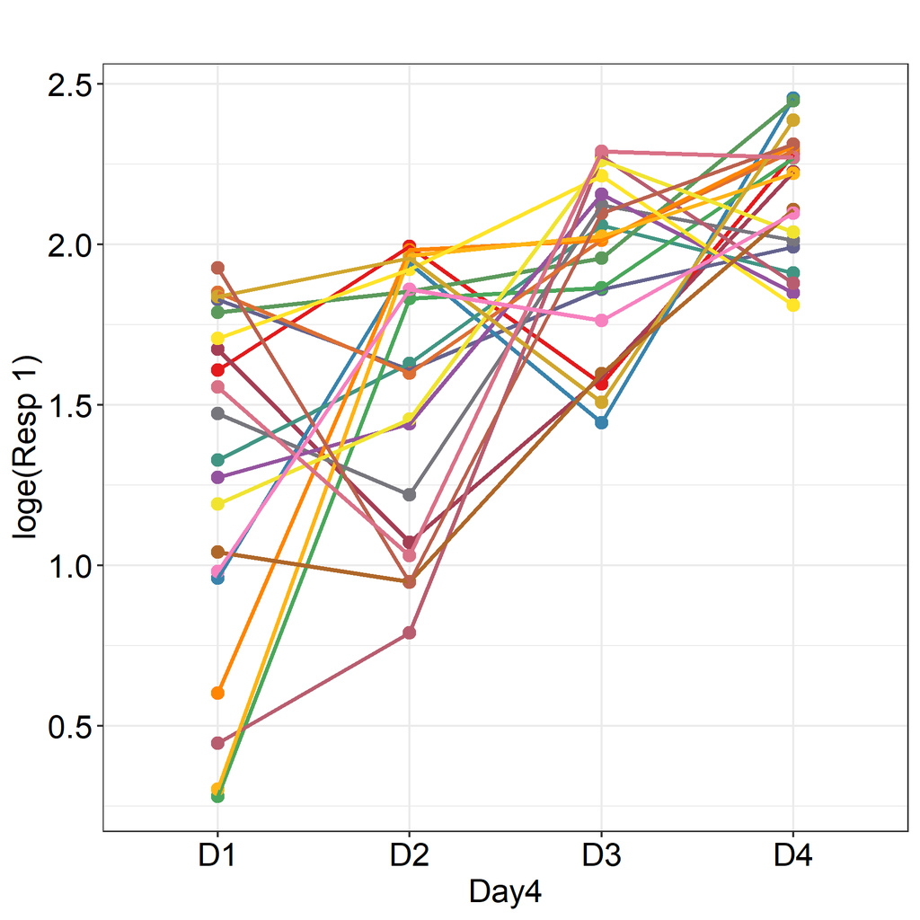

## Table of overall tests of model effects

| Effect | Num. degrees of freedom | Denom. degrees of freedom | F-value | p-value |
| --- | --- | --- | --- | --- |
| Block1 | 1 | 31.78 | 0.59 | 0.4488 |
| Day4 | 3 | 50.79 | 24.80 | < 0.0001 |

Conclusion: At the 5% level there is a statistically significant overall difference between the levels of Day4.

Tip: While it is a good idea to consider the overall tests in the above table, we should not rely on them when deciding whether or not to make pairwise comparisons.

## Diagnostic plots

### Residuals vs. predicted plot

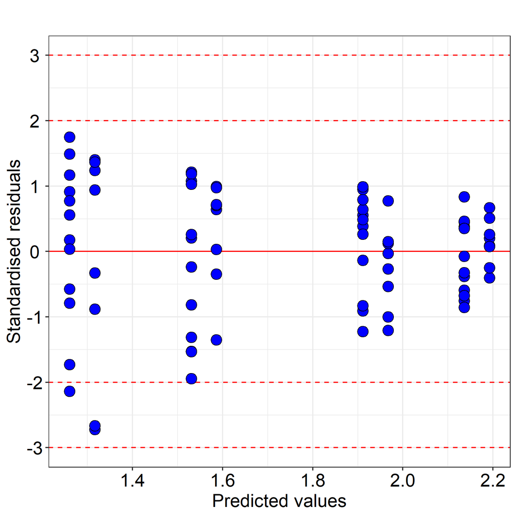

Tip: On this plot look to see if the spread of the points increases as the predicted values increase. If so the response may need transforming.

Tip: Any observation with a standardised residual less than -3 or greater than 3 (SD) should be investigated as a possible outlier.

Comment: The standardised residuals are obtained by subtracting the fitted values from the responses and dividing by the estimated within-group standard error.

### Normal probability plot

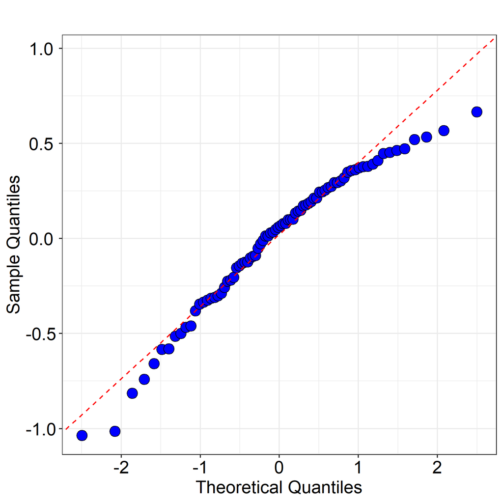

Tip: Check that the points lie along the dotted line. If not then the data may be non-normally distributed.

## Table of the least square (predicted) means with 95% confidence intervals

| Day4 | Mean | Lower 95% CI | Upper 95% CI |
| --- | --- | --- | --- |
| D1 | 1.288 | 1.118 | 1.459 |
| D2 | 1.558 | 1.388 | 1.729 |
| D3 | 1.939 | 1.769 | 2.110 |
| D4 | 2.164 | 1.994 | 2.334 |

## Plot of the least square (predicted) means with 95% confidence intervals

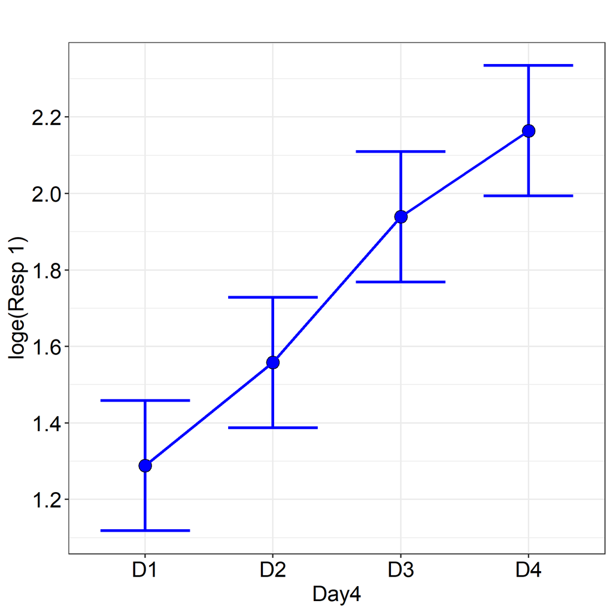

## Table of the back-transformed geometric means with 95% confidence intervals

As the response was log transformed prior to analysis the least square (predicted) means are presented on the log scale. These results can be back transformed onto the original scale. These are known as the back-transformed geometric means.

| Day4 | Mean | Lower 95% CI | Upper 95% CI |
| --- | --- | --- | --- |
| D1 | 3.627 | 3.059 | 4.301 |
| D2 | 4.750 | 4.006 | 5.633 |
| D3 | 6.954 | 5.864 | 8.246 |
| D4 | 8.706 | 7.342 | 10.324 |

## Plot of the back-transformed geometric means with 95% confidence intervals

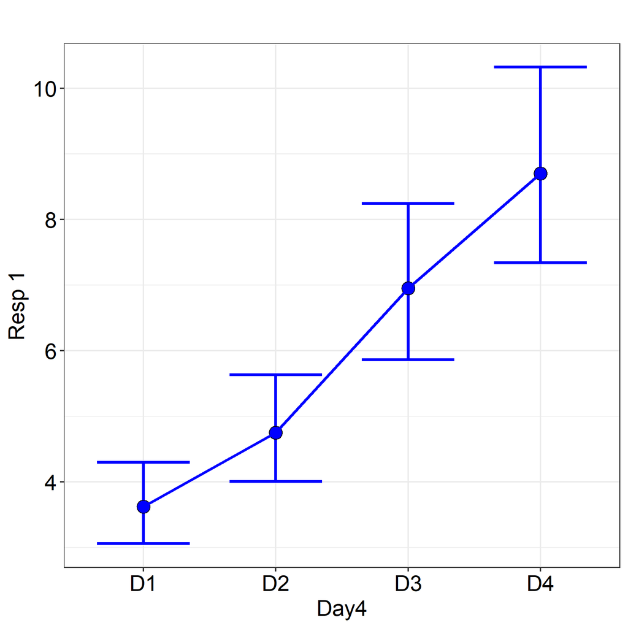

## All pairwise comparisons, without adjustment for multiplicity

| Comparison | Difference | Lower 95% CI | Upper 95% CI | Std error | p-value |
| --- | --- | --- | --- | --- | --- |
| ( D1 ) - ( D2 ) | -0.270 | -0.539 | 0.000 | 0.13 | 0.0498 |
| ( D1 ) - ( D3 ) | -0.651 | -0.885 | -0.417 | 0.12 | <0.0001 |
| ( D1 ) - ( D4 ) | -0.876 | -1.117 | -0.634 | 0.12 | <0.0001 |
| ( D2 ) - ( D3 ) | -0.381 | -0.651 | -0.112 | 0.13 | 0.0067 |
| ( D2 ) - ( D4 ) | -0.606 | -0.840 | -0.372 | 0.12 | <0.0001 |
| ( D3 ) - ( D4 ) | -0.225 | -0.494 | 0.045 | 0.13 | 0.0997 |

## All pairwise comparisons, as back-transformed ratios

As the response was log transformed prior to analysis the differences between the least square (predicted) means are presented on the log scale. These results can be back-transformed, where differences on the log scale become ratios when back-transformed.

| Comparison | Ratio | Lower 95% CI | Upper 95% CI | p-value |
| --- | --- | --- | --- | --- |
| ( D1 ) / ( D2 ) | 0.764 | 0.583 | 1.000 | 0.0498 |
| ( D1 ) / ( D3 ) | 0.522 | 0.413 | 0.659 | <0.0001 |
| ( D1 ) / ( D4 ) | 0.417 | 0.327 | 0.531 | <0.0001 |
| ( D2 ) / ( D3 ) | 0.683 | 0.522 | 0.894 | 0.0067 |
| ( D2 ) / ( D4 ) | 0.546 | 0.432 | 0.689 | <0.0001 |
| ( D3 ) / ( D4 ) | 0.799 | 0.610 | 1.046 | 0.0997 |

Conclusion: The following pairwise comparisons are statistically significant at the 5% level : [1] ( D1 ) vs. ( D2 ), [2] ( D1 ) vs. ( D3 ), [3] ( D1 ) vs. ( D4 ), [4] ( D2 ) vs. ( D3 ), [5] ( D2 ) vs. ( D4 ).

Warning: As these tests are not adjusted for multiplicity there is a risk of false positive results. Only use the pairwise comparison you planned to make a-priori, these are the so called Planned Comparisons, see Snedecor and Cochran (1989). No options are available in this module to make multiple comparison adjustments. If you wish to apply a multiple comparison adjustment to these results then use the P-value Adjustment module.

## Analysis description

The data were analysed using a repeated measures mixed model approach utilizing the mmrm R package, with treatment factor Day4 and Block1 as the blocking factor. This was followed by planned comparisons on the predicted means to compare the levels of the Day4. The response was loge transformed prior to analysis to stabilise the variance.

The first order autoregressive covariance structure was used to model the within-subject correlations. When using this structure we assumed that the variability of the responses was the same at each level of Day4. We also assumed that the correlation between responses from any pair of levels of Day4 was related to the distance between them.

The analysis implements the Kenward-Roger approximation of the degrees of freedom, see Kenward and Roger (1997).

For more information on the theoretical approaches that are implemented within this module, see Bate and Clark (2014).

## References

When referring to InVivoStat, please cite 'InVivoStat, version 5.2.0'.

Bate, S.T. and Clark, R.A. (2014). The Design and Statistical Analysis of Animal Experiments. Cambridge University Press.

Pinherio, J.C. and Bates, D.M. (2000). Mixed Effects Models in S and S-Plus. Springer-Verlag. New York, Inc.

Kenward, M.G. and Roger J.H. (1997). Small sample inference for fixed effects from restricted maximum likelihood. Biometrics. 983-997.

Snedecor, G.W. and Cochran, W.G. (1989). Statistical Methods. 8th edition; Iowa State University Press, Iowa, USA.

Venables, W.N. and Ripley, B.D. (2003). Modern Applied Statistics with S. 4th Edition; Springer. New York, Inc.